# IE582-Homework4

Random forest is performed to predict class information and mtry parameter is tuned using “tuneRF” function. Different mtry levels are considered and the best mtry is selected using OOB(out-of-bag) error. mtry=32 gives the minimum OOB error and model is generated using this value. RMSE performance is also quite good. RMSE of train data is really small and RMSE of test data is relatively small in terms of previous models.

```r
library(randomForest)
res <- tuneRF(x = traindata, y = train.class, mtryStart = 1,
    ntreeTry = 500, stepFactor = 2, improve = 0.01)
```

```
## mtry = 1  OOB error = 6.567318
## Searching left ...
## Searching right ...
## mtry = 2     OOB error = 4.615537
## 0.2971961 0.01
## mtry = 4     OOB error = 3.183978
## 0.3101608 0.01
## mtry = 8     OOB error = 2.371045
## 0.2553199 0.01
## mtry = 16    OOB error = 1.840753
## 0.2236535 0.01
## mtry = 32    OOB error = 1.725168
## 0.06279235 0.01
## mtry = 43    OOB error = 1.825139
## -0.05794902 0.01
```

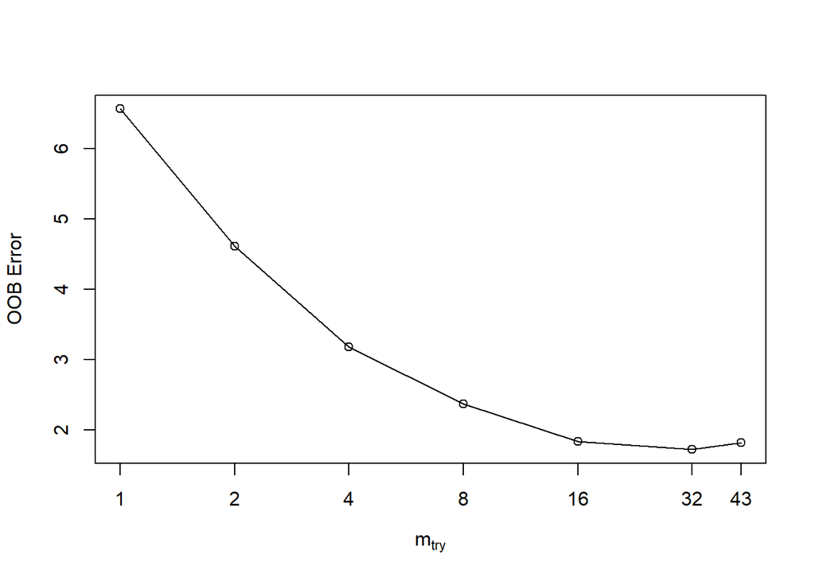

```r
# Look at results
print(res)
```

```
##    mtry OOBError
## 1     1 6.567318
## 2     2 4.615537
## 4     4 3.183978
## 8     8 2.371045
## 16   16 1.840753
## 32   32 1.725168
## 43   43 1.825139
```

```r
# Find the mtry value that minimizes OOB Error
mtry_opt <- res[, "mtry"][which.min(res[, "OOBError"])]
print(mtry_opt)
```

```
## 32
## 32
```

```r
model2 <- randomForest(train.class ~ ., data = traindata, ntree = 500,
    mtry = 32, nodesize = 5)
model2
```

```
##
## Call:
##  randomForest(formula = train.class ~ ., data = traindata, ntree = 500,      mtry = 32, nodesize = 5)
##                Type of random forest: regression
##                      Number of trees: 500
## No. of variables tried at each split: 32
##
##           Mean of squared residuals: 1.71449
##                     % Var explained: 82.14
```

```r
pred <- predict(model2, traindata)
RMSE(pred, train.class)
```

```
## [1] 0.6051317
```

```r
pred <- predict(model2, testdata)
RMSE(pred, test.class)
```

```
## [1] 1.271631
```

**5-Gradient Boosting Machine**

```r
set.seed(123)
library(dplyr)
library(gbm)
library(caret)
library(dplyr)

# create hyperparameter grid
hyper_grid <- expand.grid(n.trees = c(1000, 5000), shrinkage = c(0.01,
    0.1, 0.3), interaction.depth = c(1, 3, 5))

optimal_trees = rep(NA, nrow(hyper_grid))  # a place to dump results
min_train_error = rep(NA, nrow(hyper_grid))
min_cv_error = rep(NA, nrow(hyper_grid))  # a place to dump results

for (i in 1:nrow(hyper_grid)) {

    # reproducibility
    set.seed(123)

    # train model
    gbm.tune <- gbm(train.class ~ ., distribution = "gaussian",
        data = traindata, n.trees = hyper_grid$n.trees[i], interaction.depth = hyper_grid$interaction.depth[i],
        shrinkage = hyper_grid$shrinkage[i], cv.folds = 10, n.minobsinnode = 10)

    # add min training error and trees to grid
    optimal_trees[i] <- which.min(gbm.tune$cv.error)
    min_train_error[i] <- sqrt(min(gbm.tune$train.error))
    min_cv_error[i] <- sqrt(min(gbm.tune$cv.error))
}


cbind(hyper_grid, optimal_trees, min_train_error, min_cv_error) %>%
    dplyr::arrange(min_cv_error) %>% head(10)
```

```
##    n.trees shrinkage interaction.depth optimal_trees min_train_error
## 1     1000      0.01                 5           554     0.893854442
## 2     5000      0.01                 5           554     0.396590082
## 3     1000      0.01                 3           555     1.033641267
## 4     5000      0.01                 3           555     0.652315073
## 5     1000      0.10                 3            42     0.447901922
## 6     5000      0.10                 3            42     0.063884683
## 7     1000      0.10                 5            49     0.203035461
## 8     5000      0.10                 5            49     0.004003095
## 9     1000      0.30                 3            12     0.176116647
## 10    5000      0.30                 3            12     0.002784233
##    min_cv_error
## 1      1.356468
## 2      1.356468
## 3      1.367418
## 4      1.367418
## 5      1.382239
## 6      1.382239
## 7      1.390454
## 8      1.390454
## 9      1.400291
## 10     1.400291
```

```r
gbm.fit <- gbm(train.class ~ ., distribution = "gaussian", data = traindata,
    n.trees = 5000, interaction.depth = 5, shrinkage = 0.01,
    cv.folds = 10, n.minobsinnode = 10)

pred <- predict(gbm.fit, traindata, type = "response")
```

```
## Using 444 trees...
```

```r
RMSE(train.class, pred)
```

```
## [1] 1.081796
```

```r
pred <- predict(gbm.fit, testdata, type = "response")
```

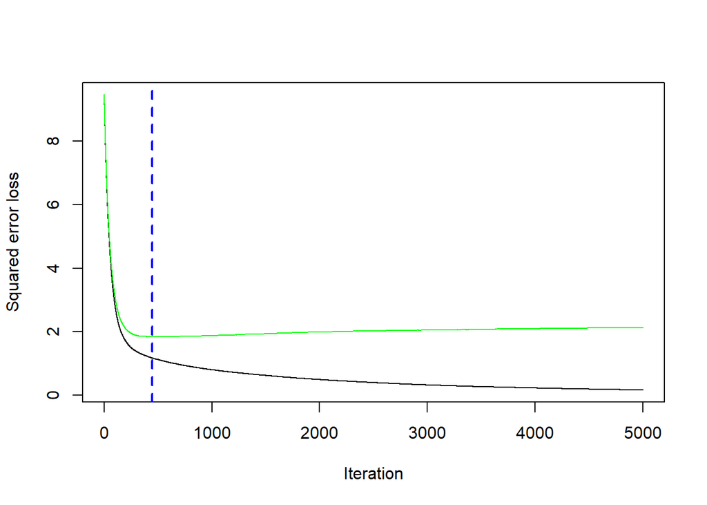

```
## Using 444 trees...
```

```r
RMSE(test.class, pred)
```

```
## [1] 1.28507
```